# hc

```python
import pandas as pd
import xarray as xr

import numpy as np

import os

import matplotlib.pyplot as plt

from utils import *
```

Target site:

```python
target    = 'marzamemi'
```

```python
maindir   = '/g100_work'
wdir      = os.path.join(maindir, 'GeoIn_Potsdam')
sisdir    = os.path.join(wdir, 'jupyter_notebooks', 'Day1_HazardCurves')
inpath    = os.path.join(sisdir, 'input')
simuldir  = os.path.join(wdir, 'simulations', target)
ncfile    = 'grid4_flowdepth.nc'
bathydir  = os.path.join(sisdir, 'bathymetry')
bathyfile = 'grid4.grd'
```

# Hazard curves

Express the probability of exceeding some intensity levels at a target site, over a specific time window.

**Input data**

1. An ensemble $\{s\}$ of scenarios $s$
2. Annual occurrence rates $\{r_i(s)\}$ of each scenario, depending on the model $i$
3. Tsunami intensity $\{I(s)\}$ for each scenario
4. Intensity threshold $I_t$ to be exceeded.

The annual exceedance-rate according to the i-th rate model $r_i$ is computed as:

$\lambda_i(I > I_t) = \sum_s P(I(s) > I_t | s) r_i(s)$

where

$ P(I(s) > I_t | s) = \begin{cases} 1 \quad \textit{if} \quad I(s) > I_t \\ 0 \quad \textit{otherwise} \end{cases} $

```python
def exceedance_curve(thresholds, intensity, rates):
    nEnsemble = rates.shape[1]
    # Annual Mean Rate of threshold exceedance
    lambda_exc = np.empty([len(thresholds), nEnsemble])
    for ith, threshold in enumerate(thresholds):
        ix_sel = intensity > threshold
        for j in range(nEnsemble):
            lambda_exc[ith, j] = rates[ix_sel,j].sum(axis=0)
    return lambda_exc
```

## Offshore case

NEAM POI offshore the target site.

```python
"""
1. Ensemble of scenarios
"""

filescen  = os.path.join(inpath, 'scenarios_SIS_wrepetition.txt')
scenarios = pd.read_csv(filescen,
                         engine = 'python',
                         sep    = ' ',
                         header = None).loc[:,0]

print(f'Number of scenarios: {scenarios.size}')

"""
2. Scenario rates.
"""

_, rates = extract_rates(os.path.join(inpath, 'rates_SIS.txt'))
print(f'Number of alternative rates for each scenario: {rates.shape[1]}')

"""
3. Tsunami intensity: max. offshore wave height
"""

filemwa  = os.path.join(inpath, 'sampled_height', f'hmax_sis_{target}.txt')
mwa_off  = pd.read_csv(filemwa,
                       engine = 'python',
                       sep    = ' ',
                       header = None).to_numpy()[:,0]
"""
4. Thresholds to be exceeded
"""
thresholds = np.array([1.000e-02, 5.000e-02, 1.000e-01, 2.000e-01,
       3.000e-01, 5.000e-01, 8.000e-01, 1.000e+00,
       1.500e+00, 2.000e+00, 2.500e+00, 3.000e+00,
       3.600e+00, 4.320e+00, 5.180e+00, 6.220e+00,
       7.460e+00])
print(f'Number of thresholds to be exceeded: {len(thresholds)}')
```

```
Number of scenarios: 3006
Number of alternative rates for each scenario: 1000
Number of thresholds to be exceeded: 17
```

```python
"""
Mean exceedance-rate and percentiles
function exceedance_curve(thresholds, intensity, rates)
"""
lambda_exc      = exceedance_curve(thresholds, mwa_off, rates)

# Mean
lambda_exc_mean = lambda_exc.mean(axis = 1)

# Percentiles of the distribution
lambda_exc_p2  = np.percentile(lambda_exc, 2,  axis = 1)
lambda_exc_p16 = np.percentile(lambda_exc, 16, axis = 1)
lambda_exc_p84 = np.percentile(lambda_exc, 84, axis = 1)
lambda_exc_p98 = np.percentile(lambda_exc, 98, axis = 1)

print(f'There are {lambda_exc.shape[1]} alternative exceedance-rate values for each of the {lambda_exc.shape[0]} thresholds')
print(f'If we take the mean over the 1000 alternatives (columns) the exceedance curve has shape: {lambda_exc_mean.shape}')
```

```
There are 1000 alternative exceedance-rate values for each of the 17 thresholds
If we take the mean over the 1000 alternatives (columns) the exceedance curve has shape: (17,)
```

```python
"""
Plot
"""

# 1. Location of the offshore POI:

poi_lon        = 15.18
poi_lat        = 36.717

# 2. Crop the domain around this point

lat_north      = poi_lat + .5
lon_west       = poi_lon - .5
lat_south      = poi_lat - .1
lon_east       = poi_lon + .2

crop_region    = [lon_west, lon_east, lat_south, lat_north]
```

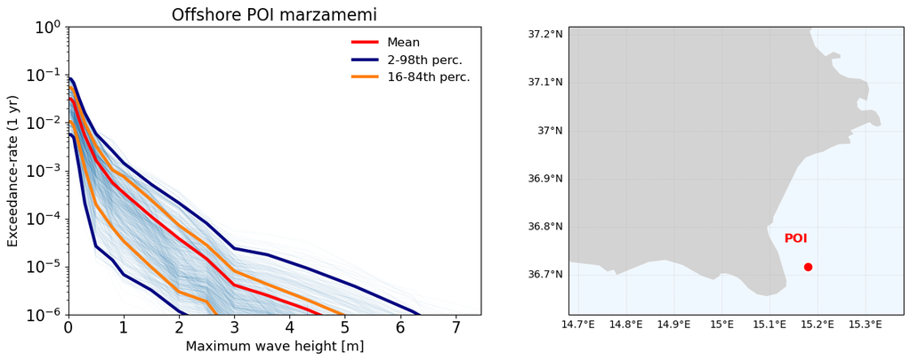

```python
plot_hazard_curves_wmap_offshore(target, poi_lon, poi_lat, crop_region, thresholds, lambda_exc)
```

```python
# Median
# 50th perc.
# lambda_exc_p50 = ....
# other percentiles

#fig, ax1 = plt.subplots(figsize=(8,5))

#ax1.plot(thresholds, lambda_exc_mean, color = 'red',        ls = '-', lw = 3,  label = 'Mean')
#ax1.plot(thresholds, lambda_exc_p2,   color = 'navy',       ls = '-', lw = 3,  label = '2-98th perc.')
#ax1.plot(thresholds, lambda_exc_p16,  color = 'tab:orange', ls = '-', lw = 3,  label = '16-84th perc.')

#--->

#ax1.plot(thresholds, lambda_exc_p84,  color = 'tab:orange', ls = '-', lw = 3,  label = '')
#ax1.plot(thresholds, lambda_exc_p98,  color = 'navy',       ls = '-', lw = 3,  label = '')

#ax1.set_yscale('log')

#ax1.set_xlim([0, thresholds.max()])
#ax1.set_ylim([1e-6, 1])

#ax1.set_xlabel("Max. wave height [m]", fontsize=13)
#ax1.set_ylabel("Exceedance-rate (1 yr)", fontsize=13)

#ax1.tick_params(labelsize=15)
#ax1.set_title(f"Offshore POI {target}", fontsize = 16)
#ax1.legend(fontsize = 12, frameon = False, loc = "upper right")
#plt.show()
```

## Onshore case

This would require reading the flow depth for each scenario, each of which consists of hundreds of thousands of grid points, and computing hazard curves at every point. The procedure is repeated for all scenarios while accumulating the corresponding contributions at each location.

```python
"""
Load bathy
"""
topobathy        = os.path.join(bathydir, bathyfile)

topo_bathy_ds    = xr.load_dataset(topobathy, engine='netcdf4')
lat              = np.asarray(topo_bathy_ds.y)
lon              = np.asarray(topo_bathy_ds.x)
elevation        = np.asarray(topo_bathy_ds.z)
z_flatten        = elevation.flatten()
npoints          = len(z_flatten)

print(f'Number of points where hazard curves should be computed: {npoints}')
```

```
Number of points where hazard curves should be computed: 660080
```

In this example, we restrict the analysis to five coastal points along the coast of Marzamemi. These points have been pinned on Google Maps 🙂 (they can be changed!)

```python
"""
Coordinates of some coastal locations: five to start
"""

lat0 = [36.746503, 36.744576, 36.740960, 36.739934, 36.735994]
lon0 = [15.111455, 15.118248, 15.119224, 15.116535, 15.117359]
```

The next step is to find their corresponding locations in the model domain.

```python
def find_nearest_idx(lat, lon, lat0, lon0):
    iy = np.abs(lat - lat0).argmin()
    ix = np.abs(lon - lon0).argmin()
    return iy, ix

npoints = len(lat0)

# corresponding indices
lat_index = []
lon_index = []

for poi in range(npoints):
    iy, ix = find_nearest_idx(lat, lon, lat0[poi], lon0[poi])
    lat_index.append(iy)
    lon_index.append(ix)
```

```python
"""
For each scenario, read
flowdepth values at the
selected points.
"""

def extract_flowdepth_point(simuldir, scenario_ids, ncfile, lats, lons):
    nscen   = len(scenario_ids)
    npoints = len(lats)
    flowdepth_pois = np.empty([nscen, npoints])
    for poi in range(npoints):
        for iscen, idscen in enumerate(scenario_ids):
            if os.path.exists(os.path.join(simuldir, 'BS', idscen)):
                tmp_flowdepth = os.path.join(simuldir, 'BS', idscen, ncfile)
            else:
                tmp_flowdepth = os.path.join(simuldir, 'PS', idscen, ncfile)
            open_file = xr.open_dataset(tmp_flowdepth, engine='netcdf4')
            flowdepth_pois[iscen, :] = open_file['z'].values[lats, lons]
    return flowdepth_pois

"""
Compute annual exceedance-rate
at each point.
"""
def computeHC(simuldir, scenario_ids, rates, ncfile, lats, lons, thresholds):
    nEnsemble     = rates.shape[1]
    npoints       = len(lats)
    lambda_total  = np.zeros((npoints, len(thresholds), nEnsemble))
    tmp_flowdepth = extract_flowdepth_point(simuldir, scenario_ids, ncfile, lats, lons)
    for poi in range(npoints):
        fdTmp = tmp_flowdepth[:, poi]
        lambdaCumTmp = exceedance_curve(thresholds, fdTmp, rates)
        lambda_total[poi, :, :] = lambdaCumTmp
    return lambda_total
```

```python
lambda_total = computeHC(simuldir, scenarios, rates, ncfile, lat_index, lon_index, thresholds)
print(f'Shape of lambda_total: {lambda_total.shape}')
```

```
Shape of lambda_total: (5, 17, 1000)
```

```python
lambda_exc_mean = lambda_total.mean(axis = 2)
lambda_exc_p2   = np.percentile(lambda_total, 2,   axis = 2)
lambda_exc_p16  = np.percentile(lambda_total, 16,  axis = 2)
lambda_exc_p84  = np.percentile(lambda_total, 84,  axis = 2)
lambda_exc_p98  = np.percentile(lambda_total, 98,  axis = 2)
print(lambda_exc_mean.shape)
```

```
(5, 17)
```

```python
"""
Select a coastal location:
ranges from 0 to 4
"""

poi = 0
```

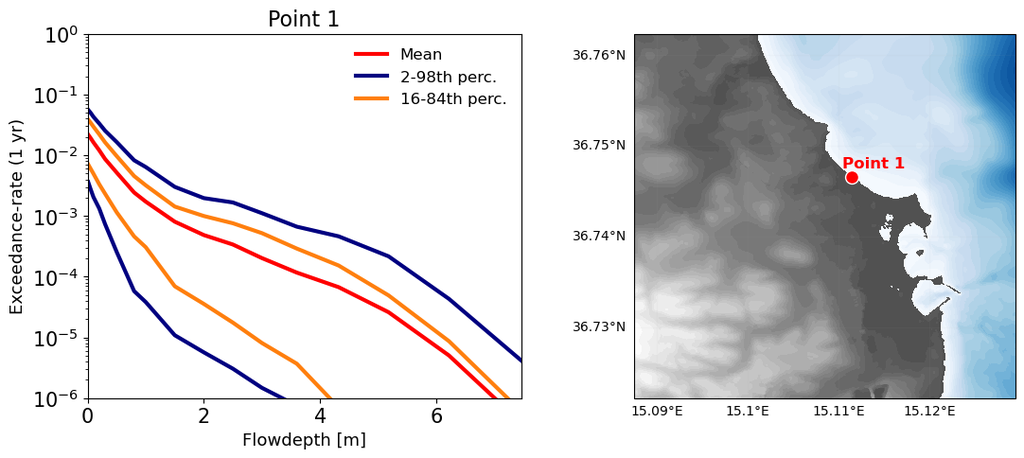

```python
lambda_tmp = lambda_total[poi, :, :].copy()
plot_hazard_curves_wmap_onshore(poi, lon0, lat0, thresholds, lambda_tmp, lon, lat, elevation)
```

## From annual exceedance rate to probability

The probability of exceeding an intensity threshold $I_t$ over a time window dt is given by

$P(I > I_t) = 1 - e^{-\lambda(I > I_t) dt}$

where $\lambda(I > I_t)$ is the annual exceedance-rate, and $dt$ is the duration of the time-window.

**Example** For $dt = 50$ years, $P = 0.1$ is the 10% probability of exceeding $I_t$ in 50 years.

The Average Return Period (ARP) is defined as:

$T = -\frac{dt}{\ln{(1-P)}}$

```python
def poisson_dist(lambda_exc, dt):
    p = 1 - np.exp(-lambda_exc*dt)
    return p

def arp(prob_exceedance, exposure_time):
    t = -np.log(1-prob_exceedance) / exposure_time
    T =  np.round(1/t)
    return T
```

```python
dt              = 50
poe_thresholds  = np.array([0.1, 0.02, 0.005]) # 10%, 2%, 0.5%
return_time     = arp(poe_thresholds, dt) # 475, 2475, 9975 yrs

for ipth, pth in enumerate(poe_thresholds):
    print(f'A probability of {pth*100}% in {dt} years corresponds to an Average Return Period (ARP) of {int(return_time[ipth])} years')
```

```
A probability of 10.0% in 50 years corresponds to an Average Return Period (ARP) of 475 years
A probability of 2.0% in 50 years corresponds to an Average Return Period (ARP) of 2475 years
A probability of 0.5% in 50 years corresponds to an Average Return Period (ARP) of 9975 years
```

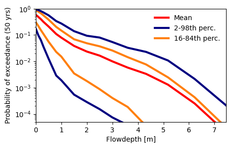

```python
"""
Same hazard curve as before,
but expressed as PoE
"""

lambda_total_tmp = lambda_total[poi, :, :]
lambda_exc       = poisson_dist(lambda_total_tmp, dt)
plot_poe_dt(thresholds, lambda_exc)
```

# From curves to hazard maps

Find the intensity value corresponding to a specific probability of exceedance.

```python
def get_intensity(hc, mih, p_th):
    n_mih = np.shape(hc)
    curve = hc
    if (p_th < curve[0] and p_th > curve[-1] ):
        for j in range(len(curve)):
            if (curve[j] < p_th):
                interp = (mih[j]-mih[j-1]) * (p_th-curve[j-1]) / (curve[j]-curve[j-1])
                z = mih[j-1]+interp
                break
    elif (p_th >= curve[0]):
           z = 0
    elif (p_th <= curve[-1]):
           z = 0
    else:
          pass

    return z
```

```python
# 1. Select a probability of exceedance (poe)

poe = 0.005   # For instance: 0.1, 0.02, 0.005...

# 2. Select an exposure time (in years)
dt  = 50
return_time     = arp(poe, dt)

print(f'ARP = {return_time} years')
```

```
ARP = 9975.0 years
```

```python
"""
Get the intensity for a given poe
"""

# 1. Mean of the distribution
lambda_exc_mean = lambda_total_tmp.mean(axis=1)
fd_hazard_map   = get_intensity(lambda_exc_mean, thresholds, poe)

# Percentiles? lambda_exc_p2, lambda_exc_p16, lambda_exc_p84, lambda_exc_p98
lambda_exc_p84 = np.percentile(lambda_total_tmp, 84, axis=1)
fd_hazard_map = get_intensity(lambda_exc_p84,  thresholds, poe)

print(f'Extracted flowdepth values for the given PoE: {fd_hazard_map} m')
```

```
Extracted flowdepth values for the given PoE: 0.7735341550100423 m
```

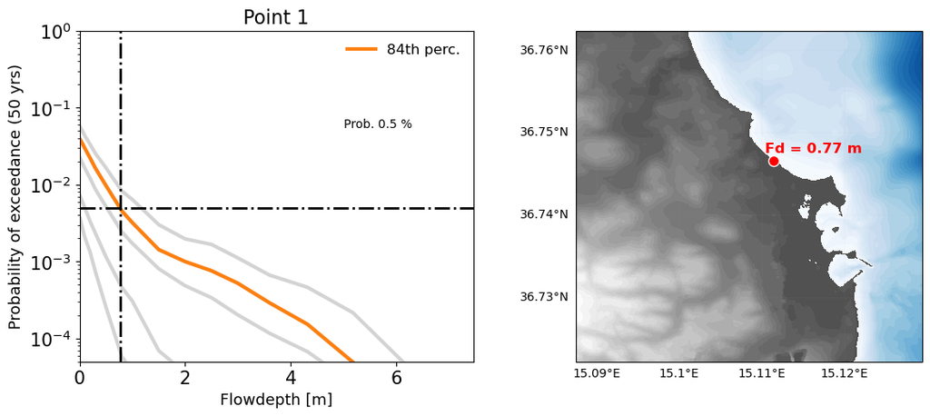

```python
# Change curve = 'mean', 'p2', 'p16', 'p84', 'p98'
plot_intensity_for_poe(poi, lon0, lat0, lon, lat, elevation, thresholds, lambda_total_tmp, fd_hazard_map, pth=poe, curve='p84')
```